# Telecom Churn Case Study_COMMENTS

## 1.Setting Environment

```python
import pandas as pd
import numpy as np
import matplotlib.pyplot as plt
import seaborn as sns
%matplotlib inline

import warnings
warnings.filterwarnings('ignore')

from sklearn import metrics
from scipy.stats import norm

pd.options.display.max_columns = None
pd.options.display.max_rows = None
```

## 2.Importing

```python
df_telecom = pd.read_csv('telecom_churn_data.csv')
```

## 3.Examining the Data

```python
df_telecom.shape
```

```
(99999, 226)
```

```python
df_telecom.describe([0.25,0.50,0.75,0.80,0.85,0.90,0.95,0.99],include='all')
```

|  | mobile_number | circle_id | loc_og_t2o_mou | std_og_t2o_mou | loc_ic_t2o_mou | last_date_of_month_6 | last_date_of_month_7 | last_date_of_month_8 | last_date_of_month_9 | arpu_6 | arpu_7 | arpu_8 | arpu_9 | onnet_mou_6 | onnet_mou_7 | onnet_mou_8 | onnet_mou_9 | offnet_mou_6 | offnet_mou_7 | offnet_mou_8 | offnet_mou_9 | roam_ic_mou_6 | roam_ic_mou_7 | roam_ic_mou_8 | roam_ic_mou_9 | roam_og_mou_6 | roam_og_mou_7 | roam_og_mou_8 | roam_og_mou_9 | … |
| --- | --- | --- | --- | --- | --- | --- | --- | --- | --- | --- | --- | --- | --- | --- | --- | --- | --- | --- | --- | --- | --- | --- | --- | --- | --- | --- | --- | --- | --- | --- |
| count | 9.999900e+04 | 99999.0 | 98981.0 | 98981.0 | 98981.0 | 99999 | 99398 | 98899 | 98340 | 99999.000000 | 99999.000000 | 99999.000000 | 99999.000000 | 96062.000000 | 96140.000000 | 94621.000000 | 92254.000000 | 96062.000000 | 96140.000000 | 94621.000000 | 92254.000000 | 96062.000000 | 96140.000000 | 94621.000000 | 92254.000000 | 96062.000000 | 96140.000000 | 94621.000000 | 92254.000000 | … |
| unique | NaN | NaN | NaN | NaN | NaN | 1 | 1 | 1 | 1 | NaN | NaN | NaN | NaN | NaN | NaN | NaN | NaN | NaN | NaN | NaN | NaN | NaN | NaN | NaN | NaN | NaN | NaN | NaN | NaN | … |
| top | NaN | NaN | NaN | NaN | NaN | 6/30/2014 | 7/31/2014 | 8/31/2014 | 9/30/2014 | NaN | NaN | NaN | NaN | NaN | NaN | NaN | NaN | NaN | NaN | NaN | NaN | NaN | NaN | NaN | NaN | NaN | NaN | NaN | NaN | … |
| freq | NaN | NaN | NaN | NaN | NaN | 99999 | 99398 | 98899 | 98340 | NaN | NaN | NaN | NaN | NaN | NaN | NaN | NaN | NaN | NaN | NaN | NaN | NaN | NaN | NaN | NaN | NaN | NaN | NaN | NaN | … |
| mean | 7.001207e+09 | 109.0 | 0.0 | 0.0 | 0.0 | NaN | NaN | NaN | NaN | 282.987358 | 278.536648 | 279.154731 | 261.645069 | 132.395875 | 133.670805 | 133.018098 | 130.302327 | 197.935577 | 197.045133 | 196.574803 | 190.337222 | 9.950013 | 7.149898 | 7.292981 | 6.343841 | 13.911337 | 9.818732 | 9.971890 | 8.555519 | … |
| std | 6.956694e+05 | 0.0 | 0.0 | 0.0 | 0.0 | NaN | NaN | NaN | NaN | 328.439770 | 338.156291 | 344.474791 | 341.998630 | 297.207406 | 308.794148 | 308.951589 | 308.477668 | 316.851613 | 325.862803 | 327.170662 | 319.396092 | 72.825411 | 73.447948 | 68.402466 | 57.137537 | 71.443196 | 58.455762 | 64.713221 | 58.438186 | … |
| min | 7.000000e+09 | 109.0 | 0.0 | 0.0 | 0.0 | NaN | NaN | NaN | NaN | -2258.709000 | -2014.045000 | -945.808000 | -1899.505000 | 0.000000 | 0.000000 | 0.000000 | 0.000000 | 0.000000 | 0.000000 | 0.000000 | 0.000000 | 0.000000 | 0.000000 | 0.000000 | 0.000000 | 0.000000 | 0.000000 | 0.000000 | 0.000000 | … |
| 25% | 7.000606e+09 | 109.0 | 0.0 | 0.0 | 0.0 | NaN | NaN | NaN | NaN | 93.411500 | 86.980500 | 84.126000 | 62.685000 | 7.380000 | 6.660000 | 6.460000 | 5.330000 | 34.730000 | 32.190000 | 31.630000 | 27.130000 | 0.000000 | 0.000000 | 0.000000 | 0.000000 | 0.000000 | 0.000000 | 0.000000 | 0.000000 | … |
| 50% | 7.001205e+09 | 109.0 | 0.0 | 0.0 | 0.0 | NaN | NaN | NaN | NaN | 197.704000 | 191.640000 | 192.080000 | 176.849000 | 34.310000 | 32.330000 | 32.360000 | 29.840000 | 96.310000 | 91.735000 | 92.140000 | 87.290000 | 0.000000 | 0.000000 | 0.000000 | 0.000000 | 0.000000 | 0.000000 | 0.000000 | 0.000000 | … |
| 75% | 7.001812e+09 | 109.0 | 0.0 | 0.0 | 0.0 | NaN | NaN | NaN | NaN | 371.060000 | 365.344500 | 369.370500 | 353.466500 | 118.740000 | 115.595000 | 115.860000 | 112.130000 | 231.860000 | 226.815000 | 228.260000 | 220.505000 | 0.000000 | 0.000000 | 0.000000 | 0.000000 | 0.000000 | 0.000000 | 0.000000 | 0.000000 | … |
| 80% | 7.001930e+09 | 109.0 | 0.0 | 0.0 | 0.0 | NaN | NaN | NaN | NaN | 429.792400 | 423.772600 | 427.783200 | 412.068200 | 158.906000 | 158.182000 | 156.840000 | 152.890000 | 283.806000 | 279.780000 | 281.440000 | 273.022000 | 0.060000 | 0.000000 | 0.000000 | 0.000000 | 0.160000 | 0.000000 | 0.000000 | 0.000000 | … |
| 85% | 7.002050e+09 | 109.0 | 0.0 | 0.0 | 0.0 | NaN | NaN | NaN | NaN | 507.231500 | 501.389100 | 506.029100 | 489.221700 | 223.705500 | 224.281500 | 223.990000 | 219.180500 | 357.257000 | 357.696000 | 361.190000 | 349.560000 | 3.330000 | 0.280000 | 0.230000 | 0.000000 | 6.140000 | 0.330000 | 0.130000 | 0.000000 | … |
| 90% | 7.002174e+09 | 109.0 | 0.0 | 0.0 | 0.0 | NaN | NaN | NaN | NaN | 620.075400 | 617.252000 | 618.160400 | 601.537000 | 344.102000 | 348.035000 | 345.030000 | 342.890000 | 477.325000 | 480.431000 | 486.310000 | 471.031000 | 11.810000 | 5.060000 | 5.340000 | 3.630000 | 22.480000 | 9.930000 | 9.130000 | 6.060000 | … |
| 95% | 7.002291e+09 | 109.0 | 0.0 | 0.0 | 0.0 | NaN | NaN | NaN | NaN | 829.488200 | 828.357200 | 833.303300 | 805.107200 | 612.407500 | 624.835500 | 620.690000 | 617.232500 | 727.879000 | 744.225000 | 734.860000 | 720.120500 | 40.640000 | 23.140000 | 24.460000 | 19.240000 | 69.110000 | 42.990000 | 42.110000 | 33.930000 | … |
| 99% | 7.002387e+09 | 109.0 | 0.0 | 0.0 | 0.0 | NaN | NaN | NaN | NaN | 1410.792540 | 1428.685880 | 1455.539960 | 1402.445660 | 1431.760500 | 1478.533300 | 1480.334000 | 1445.766400 | 1539.535800 | 1549.379500 | 1530.398000 | 1521.328700 | 219.847000 | 154.483200 | 162.940000 | 140.983500 | 285.995800 | 220.988600 | 222.180000 | 192.789900 | … |
| max | 7.002411e+09 | 109.0 | 0.0 | 0.0 | 0.0 | NaN | NaN | NaN | NaN | 27731.088000 | 35145.834000 | 33543.624000 | 38805.617000 | 7376.710000 | 8157.780000 | 10752.560000 | 10427.460000 | 8362.360000 | 9667.130000 | 14007.340000 | 10310.760000 | 13724.380000 | 15371.040000 | 13095.360000 | 8464.030000 | 3775.110000 | 2812.040000 | 5337.040000 | 4428.460000 | … |

Looking at the statistics above, the following can be observed:

```
There are a number of columns that have single value, hence that should be deleted
There are a number of columns with outliers that should be treated but with caution
There are a number of columns with missing values that should be furhter investigated and imputed or deleted
```

## 4) Data Cleaning

### 4.1) Handling Missing Values

```python
null_columns = round(100*(df_telecom.isnull().sum()/len(df_telecom.index)), 2)
null_columns = null_columns[null_columns>0]
null_columns.sort_values(inplace=True, ascending=False)
print ('Total Columns with missing values = ',len(null_columns))
null_columns
```

```
Total Columns with missing values =  166
```

```
count_rech_3g_6             74.85
fb_user_6                   74.85
date_of_last_rech_data_6    74.85
count_rech_2g_6             74.85
night_pck_user_6            74.85
av_rech_amt_data_6          74.85
total_rech_data_6           74.85
arpu_2g_6                   74.85
max_rech_data_6             74.85
arpu_3g_6                   74.85
arpu_3g_7                   74.43
count_rech_3g_7             74.43
count_rech_2g_7             74.43
av_rech_amt_data_7          74.43
max_rech_data_7             74.43
arpu_2g_7                   74.43
night_pck_user_7            74.43
date_of_last_rech_data_7    74.43
fb_user_7                   74.43
total_rech_data_7           74.43
total_rech_data_9           74.08
count_rech_2g_9             74.08
max_rech_data_9             74.08
date_of_last_rech_data_9    74.08
fb_user_9                   74.08
count_rech_3g_9             74.08
night_pck_user_9            74.08
av_rech_amt_data_9          74.08
arpu_2g_9                   74.08
arpu_3g_9                   74.08
count_rech_2g_8             73.66
arpu_2g_8                   73.66
fb_user_8                   73.66
count_rech_3g_8             73.66
night_pck_user_8            73.66
date_of_last_rech_data_8    73.66
total_rech_data_8           73.66
arpu_3g_8                   73.66
max_rech_data_8             73.66
av_rech_amt_data_8          73.66
```

[output cut: 112 more lines]

```
loc_og_t2c_mou_7             3.86
loc_ic_t2f_mou_7             3.86
loc_ic_mou_7                 3.86
loc_og_t2f_mou_7             3.86
std_ic_t2t_mou_7             3.86
date_of_last_rech_8          3.62
date_of_last_rech_7          1.77
last_date_of_month_9         1.66
date_of_last_rech_6          1.61
last_date_of_month_8         1.10
loc_ic_t2o_mou               1.02
std_og_t2o_mou               1.02
loc_og_t2o_mou               1.02
last_date_of_month_7         0.60
dtype: float64
```

#### Dropping date columns since we will not be using them in our analysis . The monthly breakup is already available

```python
date_columns = ['date_of_last_rech_data_6','date_of_last_rech_data_7','date_of_last_rech_data_9','date_of_last_rech_data_8',
                'date_of_last_rech_9','date_of_last_rech_8','date_of_last_rech_7','date_of_last_rech_6',
                'last_date_of_month_9','last_date_of_month_8','last_date_of_month_7','last_date_of_month_6']
df_telecom = df_telecom.drop(date_columns , axis = 1)
```

```python
#  THESE COLUMNS HAVE HIGH MISSING VALUES.THEY REPEAT FOR ALL 4 MONTHS WE EXAMINE THE DATA TO SEE WHAT TO KEEP.
# 40 COLUMNS IN ALL. 10 FOR EACH MONTH. WE HAVE ALREADY DROPPED DATE COLUMNS ******
# we will do a preliminary analysis and decide to drop or keep the columns
# will be dropped / imputed for all 4 months
```

count_rech_3g_6 74.85 - DROP fb_user_6 74.85 - Impute with 3 a new category  
date_of_last_rech_data_6 74.85 - (DROPPED)  
count_rech_2g_6 74.85 - DROP  
night_pck_user_6 74.85 - DROP max 700 users use this hence dropping witll not reliably influence model. av_rech_amt_data_6 74.85 - KEEP revenue imputing with 0 total_rech_data_6 74.85 - KEEP count imputing with 0 arpu_2g_6 74.85 - DROP data available in other columns like mou max_rech_data_6 74.85 - DROP arpu_3g_6 74.85 - DROP data available in other columns like mou

```python
internet_columns = ['count_rech_3g_6','night_pck_user_6','max_rech_data_6','count_rech_2g_6',
                'count_rech_3g_7','night_pck_user_7','max_rech_data_7','count_rech_2g_7',
                'count_rech_3g_8','night_pck_user_8','max_rech_data_8','count_rech_2g_8',
                'count_rech_3g_9','night_pck_user_9','max_rech_data_9','count_rech_2g_9',
                'arpu_2g_6','arpu_3g_6','arpu_2g_7','arpu_3g_7' ,
                'arpu_2g_8','arpu_3g_8','arpu_2g_9','arpu_3g_9']

df_telecom = df_telecom.drop(internet_columns , axis = 1)
```

```python
# DROPPING ID AND MOBILE NUMBER
df_telecom = df_telecom.drop(['mobile_number','circle_id'] , axis = 1)
```

#### Imputing some columns with high missing values with zero

```python
# imputing with 0
# Since they are amount value, impuring with 0 means not recharging

impute_zero_columns = ['av_rech_amt_data_6','total_rech_data_6',
                'av_rech_amt_data_7','total_rech_data_7',
                'av_rech_amt_data_8','total_rech_data_8',
                'av_rech_amt_data_9','total_rech_data_9'
                ]

for col in impute_zero_columns:
    df_telecom[col].fillna(0,inplace=True)
#
# Identified these columns as categorial variable and missing value is imputed with 3 as a new category
impute_fb_columns = ['fb_user_6','fb_user_7','fb_user_8','fb_user_9']

for col in impute_fb_columns:
    df_telecom[col].fillna(3,inplace=True)

df_telecom.shape
```

```
(99999, 188)
```

#### Imputing the columns with lower percentage of missing values with median of those columns

```python
#         1) Most of them have around 3.5%-5%  missing
#         2) Numeric columns recording MOU ie minutes of usage
#         3) There are 29 columns repeated across all the 4 months 116 columns in all.
#         4) 9th month has around 7%. those columns will not be considered for the modelling.
```

std_og_t2f_mou_6 3.94 onnet_mou_6 3.94 loc_og_t2t_mou_6 3.94 roam_ic_mou_6 3.94 std_og_t2m_mou_6 3.94 roam_og_mou_6 3.94 loc_og_t2c_mou_6 3.94 std_og_t2t_mou_6 3.94 offnet_mou_6 3.94 loc_og_t2f_mou_6 3.94 loc_og_mou_6 3.94 loc_og_t2m_mou_6 3.94 loc_ic_t2f_mou_6 3.94 std_og_t2c_mou_6 3.94 og_others_6 3.94 std_ic_t2m_mou_6 3.94 std_ic_t2t_mou_6 3.94 std_ic_t2o_mou_6 3.94 loc_ic_mou_6 3.94 std_ic_mou_6 3.94 loc_ic_t2m_mou_6 3.94 spl_ic_mou_6 3.94 std_ic_t2f_mou_6 3.94 loc_ic_t2t_mou_6 3.94 isd_ic_mou_6 3.94 spl_og_mou_6 3.94 ic_others_6 3.94 isd_og_mou_6 3.94 std_og_mou_6 3.94

```python
null_columns = round(100*(df_telecom.isnull().sum()/len(df_telecom.index)), 2)
null_columns = null_columns[null_columns>0]
null_columns.sort_values(inplace=True, ascending=False)
print ('Total Columns with missing values = ',len(null_columns))
```

```
Total Columns with missing values =  119
```

```python
MOU_COLUMNS_TO_IMPUTE_6 = ['std_og_t2f_mou_6','onnet_mou_6','loc_og_t2t_mou_6','roam_ic_mou_6','std_og_t2m_mou_6',
                         'roam_og_mou_6', 'loc_og_t2c_mou_6', 'std_og_t2t_mou_6' , 'offnet_mou_6' , 'loc_og_t2f_mou_6',
                         'loc_og_mou_6', 'loc_og_t2m_mou_6' , 'loc_ic_t2f_mou_6' , 'std_og_t2c_mou_6' ,'og_others_6',
                         'std_ic_t2m_mou_6' , 'std_ic_t2t_mou_6' , 'std_ic_t2o_mou_6' ,'loc_ic_mou_6' ,'std_ic_mou_6',
                         'loc_ic_t2m_mou_6' , 'spl_ic_mou_6' , 'std_ic_t2f_mou_6' , 'loc_ic_t2t_mou_6' , 'isd_ic_mou_6',
                         'spl_og_mou_6' ,'ic_others_6', 'isd_og_mou_6' ,'std_og_mou_6']

for col in MOU_COLUMNS_TO_IMPUTE_6:
    df_telecom[col].fillna(df_telecom[col].median(),inplace=True)

MOU_COLUMNS_TO_IMPUTE_7 = ['std_og_t2f_mou_7','onnet_mou_7','loc_og_t2t_mou_7','roam_ic_mou_7','std_og_t2m_mou_7',
                         'roam_og_mou_7', 'loc_og_t2c_mou_7', 'std_og_t2t_mou_7' , 'offnet_mou_7' , 'loc_og_t2f_mou_7',
                         'loc_og_mou_7', 'loc_og_t2m_mou_7' , 'loc_ic_t2f_mou_7' , 'std_og_t2c_mou_7' ,'og_others_7',
                         'std_ic_t2m_mou_7' , 'std_ic_t2t_mou_7' , 'std_ic_t2o_mou_7' ,'loc_ic_mou_7' ,'std_ic_mou_7',
                         'loc_ic_t2m_mou_7' , 'spl_ic_mou_7' , 'std_ic_t2f_mou_7' , 'loc_ic_t2t_mou_7' , 'isd_ic_mou_7',
                         'spl_og_mou_7' ,'ic_others_7', 'isd_og_mou_7' ,'std_og_mou_7']

for col in MOU_COLUMNS_TO_IMPUTE_7:
    df_telecom[col].fillna(df_telecom[col].median(),inplace=True)

MOU_COLUMNS_TO_IMPUTE_8 = ['std_og_t2f_mou_8','onnet_mou_8','loc_og_t2t_mou_8','roam_ic_mou_8','std_og_t2m_mou_8',
                         'roam_og_mou_8', 'loc_og_t2c_mou_8', 'std_og_t2t_mou_8' , 'offnet_mou_8' , 'loc_og_t2f_mou_8',
                         'loc_og_mou_8', 'loc_og_t2m_mou_8' , 'loc_ic_t2f_mou_8' , 'std_og_t2c_mou_8' ,'og_others_8',
                         'std_ic_t2m_mou_8' , 'std_ic_t2t_mou_8' , 'std_ic_t2o_mou_8' ,'loc_ic_mou_8' ,'std_ic_mou_8',
                         'loc_ic_t2m_mou_8' , 'spl_ic_mou_8' , 'std_ic_t2f_mou_8' , 'loc_ic_t2t_mou_8' , 'isd_ic_mou_8',
                         'spl_og_mou_8' ,'ic_others_8', 'isd_og_mou_8' ,'std_og_mou_8']

for col in MOU_COLUMNS_TO_IMPUTE_8:
    df_telecom[col].fillna(df_telecom[col].median(),inplace=True)

MOU_COLUMNS_TO_IMPUTE_9 = ['std_og_t2f_mou_9','onnet_mou_9','loc_og_t2t_mou_9','roam_ic_mou_9','std_og_t2m_mou_9',
                         'roam_og_mou_9', 'loc_og_t2c_mou_9', 'std_og_t2t_mou_9' , 'offnet_mou_9' , 'loc_og_t2f_mou_9',
                         'loc_og_mou_9', 'loc_og_t2m_mou_9' , 'loc_ic_t2f_mou_9' , 'std_og_t2c_mou_9' ,'og_others_9',
                         'std_ic_t2m_mou_9' , 'std_ic_t2t_mou_9' , 'std_ic_t2o_mou_9' ,'loc_ic_mou_9' ,'std_ic_mou_9',
                         'loc_ic_t2m_mou_9' , 'spl_ic_mou_9' , 'std_ic_t2f_mou_9' , 'loc_ic_t2t_mou_9' , 'isd_ic_mou_9',
                         'spl_og_mou_9' ,'ic_others_9', 'isd_og_mou_9' ,'std_og_mou_9']

for col in MOU_COLUMNS_TO_IMPUTE_9:
    df_telecom[col].fillna(df_telecom[col].median(),inplace=True)
```

```python
null_columns = round(100*(df_telecom.isnull().sum()/len(df_telecom.index)), 2)
null_columns = null_columns[null_columns>0]
null_columns.sort_values(inplace=True, ascending=False)
print ('Total Columns with missing values = ',len(null_columns))
null_columns
```

```
Total Columns with missing values =  3
```

```
loc_ic_t2o_mou    1.02
std_og_t2o_mou    1.02
loc_og_t2o_mou    1.02
dtype: float64
```

#### Using the imputer for a few columns

```python
# Columns to imput
remaining_cols= ['loc_ic_t2o_mou','std_og_t2o_mou','loc_og_t2o_mou']



# THIS CAN BE USED FOR INTERATIVE IMPUTER

# from sklearn.experimental import enable_iterative_imputer
# from sklearn.impute import IterativeImputer
#imp = IterativeImputer(random_state=100,missing_values=np.nan, sample_posterior=False, initial_strategy='median')
#df_telecom[df_telecom.columns] = pd.DataFrame(imp.fit_transform(df_telecom[df_telecom.columns]), columns=df_telecom.columns)

# Since the iterative imputer takes. Have added less columns since it takes lots of time otherwise
for col in remaining_cols:
    df_telecom[col].fillna(df_telecom[col].median(),inplace=True)
```

```python
null_columns = round(100*(df_telecom.isnull().sum()/len(df_telecom.index)), 2)
null_columns = null_columns[null_columns>0]
null_columns.sort_values(inplace=True, ascending=False)
print ('Total Columns with missing values = ',len(null_columns))
null_columns
```

```
Total Columns with missing values =  0
```

```
Series([], dtype: float64)
```

### 4.2. Identifying and Removing data columns with single unique value¶

```python
# Getting columns with single unique value and check if there is any missing value
single_value_columns=[]
for col in df_telecom.columns:
    if df_telecom[col].nunique()==1:
        single_value_columns.append(col)
print('Total variables {} to remove '.format(len(single_value_columns)))

# Checking single value variables missing values
print(df_telecom[single_value_columns].isnull().sum())
# Has single value and some missing values. So we will remove them as imputing will also result in single value

# Removing single value columns
df_telecom=df_telecom.drop(columns=single_value_columns,axis=1)
```

```
Total variables 11 to remove
loc_og_t2o_mou      0
std_og_t2o_mou      0
loc_ic_t2o_mou      0
std_og_t2c_mou_6    0
std_og_t2c_mou_7    0
std_og_t2c_mou_8    0
std_og_t2c_mou_9    0
std_ic_t2o_mou_6    0
std_ic_t2o_mou_7    0
std_ic_t2o_mou_8    0
std_ic_t2o_mou_9    0
dtype: int64
```

```python
df_telecom.shape
```

```
(99999, 177)
```

#### Finding probable categorical columns

```python
# Facebook seems categorical and has 3 values since it was imputed with 3

# monthly packs have many values can be made 0 and 1 if packs taken since freqencies are very low beyond 1

single_value_vars2=[]
for col in df_telecom.columns:
    if df_telecom[col].nunique()<= 15:
        single_value_vars2.append(col)
print(single_value_vars2)
print('Total variables {} to remove '.format(len(single_value_vars2)))

# Checking two unique value variables missing values
print(df_telecom[single_value_vars2].nunique())
```

```
['monthly_2g_6', 'monthly_2g_7', 'monthly_2g_8', 'monthly_2g_9', 'monthly_3g_6', 'monthly_3g_7', 'monthly_3g_8', 'monthly_3g_9', 'fb_user_6', 'fb_user_7', 'fb_user_8', 'fb_user_9']
Total variables 12 to remove
monthly_2g_6     5
monthly_2g_7     6
monthly_2g_8     6
monthly_2g_9     5
monthly_3g_6    12
monthly_3g_7    15
monthly_3g_8    12
monthly_3g_9    11
fb_user_6        3
fb_user_7        3
fb_user_8        3
fb_user_9        3
dtype: int64
```

```python
# Extracting column types
cat_columns =['monthly_2g_6', 'monthly_2g_7', 'monthly_2g_8', 'monthly_2g_9', 'monthly_3g_6', 'monthly_3g_7', 'monthly_3g_8', 'monthly_3g_9', 'fb_user_6', 'fb_user_7', 'fb_user_8', 'fb_user_9']
# change columns types
df_telecom[cat_columns] = df_telecom[cat_columns].apply(lambda column: column.astype("category"), axis=0)
```

```python
# converting categories with infrequent categories into 1 . here 1 means subscribed 0 means did not subscribe

pack_columns=['monthly_2g_6', 'monthly_2g_7', 'monthly_2g_8', 'monthly_2g_9', 'monthly_3g_6', 'monthly_3g_7', 'monthly_3g_8', 'monthly_3g_9']

for col in pack_columns:
    df_telecom[col] = df_telecom[col].apply(lambda x: 1 if x > 1 else x )
```

```python
df_telecom.head()
```

|  | arpu_6 | arpu_7 | arpu_8 | arpu_9 | onnet_mou_6 | onnet_mou_7 | onnet_mou_8 | onnet_mou_9 | offnet_mou_6 | offnet_mou_7 | offnet_mou_8 | offnet_mou_9 | roam_ic_mou_6 | roam_ic_mou_7 | roam_ic_mou_8 | roam_ic_mou_9 | roam_og_mou_6 | roam_og_mou_7 | roam_og_mou_8 | roam_og_mou_9 | loc_og_t2t_mou_6 | loc_og_t2t_mou_7 | loc_og_t2t_mou_8 | loc_og_t2t_mou_9 | loc_og_t2m_mou_6 | loc_og_t2m_mou_7 | loc_og_t2m_mou_8 | loc_og_t2m_mou_9 | loc_og_t2f_mou_6 | … |
| --- | --- | --- | --- | --- | --- | --- | --- | --- | --- | --- | --- | --- | --- | --- | --- | --- | --- | --- | --- | --- | --- | --- | --- | --- | --- | --- | --- | --- | --- | --- |
| 0 | 197.385 | 214.816 | 213.803 | 21.100 | 34.31 | 32.33 | 0.00 | 29.84 | 96.31 | 91.735 | 0.00 | 87.29 | 0.0 | 0.00 | 0.00 | 0.00 | 0.0 | 0.00 | 0.00 | 0.00 | 11.91 | 11.61 | 0.00 | 11.26 | 41.03 | 40.43 | 0.00 | 39.12 | 0.00 | … |
| 1 | 34.047 | 355.074 | 268.321 | 86.285 | 24.11 | 78.68 | 7.68 | 18.34 | 15.74 | 99.840 | 304.76 | 53.76 | 0.0 | 0.00 | 0.00 | 0.00 | 0.0 | 0.00 | 0.00 | 0.00 | 23.88 | 74.56 | 7.68 | 18.34 | 11.51 | 75.94 | 291.86 | 53.76 | 0.00 | … |
| 2 | 167.690 | 189.058 | 210.226 | 290.714 | 11.54 | 55.24 | 37.26 | 74.81 | 143.33 | 220.590 | 208.36 | 118.91 | 0.0 | 0.00 | 0.00 | 38.49 | 0.0 | 0.00 | 0.00 | 70.94 | 7.19 | 28.74 | 13.58 | 14.39 | 29.34 | 16.86 | 38.46 | 28.16 | 24.11 | … |
| 3 | 221.338 | 251.102 | 508.054 | 389.500 | 99.91 | 54.39 | 310.98 | 241.71 | 123.31 | 109.010 | 71.68 | 113.54 | 0.0 | 54.86 | 44.38 | 0.00 | 0.0 | 28.09 | 39.04 | 0.00 | 73.68 | 34.81 | 10.61 | 15.49 | 107.43 | 83.21 | 22.46 | 65.46 | 1.91 | … |
| 4 | 261.636 | 309.876 | 238.174 | 163.426 | 50.31 | 149.44 | 83.89 | 58.78 | 76.96 | 91.880 | 124.26 | 45.81 | 0.0 | 0.00 | 0.00 | 0.00 | 0.0 | 0.00 | 0.00 | 0.00 | 50.31 | 149.44 | 83.89 | 58.78 | 67.64 | 91.88 | 124.26 | 37.89 | 0.00 | … |

### 5 ) Finding high networth customers from total recharge amount for month 6,7 and data 6,7

```python
df_telecom['ave_cus_rech_6_7'] = (df_telecom['total_rech_amt_6']+df_telecom['total_rech_amt_7']
                                                +df_telecom['av_rech_amt_data_6']+ df_telecom['av_rech_amt_data_7'])/2
```

```python
df_telecom.head(2)
```

|  | arpu_6 | arpu_7 | arpu_8 | arpu_9 | onnet_mou_6 | onnet_mou_7 | onnet_mou_8 | onnet_mou_9 | offnet_mou_6 | offnet_mou_7 | offnet_mou_8 | offnet_mou_9 | roam_ic_mou_6 | roam_ic_mou_7 | roam_ic_mou_8 | roam_ic_mou_9 | roam_og_mou_6 | roam_og_mou_7 | roam_og_mou_8 | roam_og_mou_9 | loc_og_t2t_mou_6 | loc_og_t2t_mou_7 | loc_og_t2t_mou_8 | loc_og_t2t_mou_9 | loc_og_t2m_mou_6 | loc_og_t2m_mou_7 | loc_og_t2m_mou_8 | loc_og_t2m_mou_9 | loc_og_t2f_mou_6 | … |
| --- | --- | --- | --- | --- | --- | --- | --- | --- | --- | --- | --- | --- | --- | --- | --- | --- | --- | --- | --- | --- | --- | --- | --- | --- | --- | --- | --- | --- | --- | --- |
| 0 | 197.385 | 214.816 | 213.803 | 21.100 | 34.31 | 32.33 | 0.00 | 29.84 | 96.31 | 91.735 | 0.00 | 87.29 | 0.0 | 0.0 | 0.0 | 0.0 | 0.0 | 0.0 | 0.0 | 0.0 | 11.91 | 11.61 | 0.00 | 11.26 | 41.03 | 40.43 | 0.00 | 39.12 | 0.0 | … |
| 1 | 34.047 | 355.074 | 268.321 | 86.285 | 24.11 | 78.68 | 7.68 | 18.34 | 15.74 | 99.840 | 304.76 | 53.76 | 0.0 | 0.0 | 0.0 | 0.0 | 0.0 | 0.0 | 0.0 | 0.0 | 23.88 | 74.56 | 7.68 | 18.34 | 11.51 | 75.94 | 291.86 | 53.76 | 0.0 | … |

```python
df_telecom['ave_cus_rech_6_7'].describe([0,0.25,0.50,0.70,0.80,0.85,0.90,0.95,0.99],include='all')
```

```
count    99999.000000
mean       375.158217
std        422.446506
min          0.000000
0%           0.000000
25%        125.000000
50%        263.500000
70%        431.000000
80%        561.000000
85%        658.650000
90%        808.000000
95%       1075.550000
99%       1844.020000
max      37762.500000
Name: ave_cus_rech_6_7, dtype: float64
```

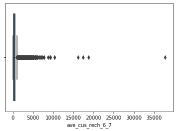

```python
sns.boxplot(df_telecom['ave_cus_rech_6_7'])
```

### 6) Splitting High Networth Customers. Keeping the quantile values at .7

```python
quantiles = pd.qcut(df_telecom['ave_cus_rech_6_7'], [0, .7, 1.], labels=["non-HVC", "HVC"])
df_telecom = df_telecom.assign(Customer_Type=quantiles.values)
```

```python
DF_TELECOM_HVC = df_telecom[df_telecom.Customer_Type == "HVC"]
```

### Data Frame with only HNI customers

```python
DF_TELECOM_HVC.shape
```

```
(29949, 179)
```

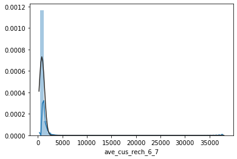

```python
sns.distplot(DF_TELECOM_HVC['ave_cus_rech_6_7'] , fit=norm);
```

```python
# Drop derived recharge columns
recharge_columns = ['total_rech_data_6',
                'total_rech_data_7','total_rech_data_8',
                'total_rech_data_9','ave_cus_rech_6_7']

DF_TELECOM_HVC = DF_TELECOM_HVC.drop(recharge_columns , axis = 1)
```

### 7) Calculating Churn data and churns

### Calculate the target variable. Using total ic , total outgoing and data usage for month 9.

#### If all these are call mou and data volume is zero then we consider the person has churned. Else we assume they are using the network

```python
DF_TELECOM_HVC['DATA_usage_9'] = DF_TELECOM_HVC['vol_3g_mb_9'] + DF_TELECOM_HVC['vol_2g_mb_9']

DF_TELECOM_HVC['MOU_usage_9'] = DF_TELECOM_HVC['total_og_mou_9'] + DF_TELECOM_HVC['total_ic_mou_9']

churned = (lambda x,y: '0' if((x > 0) or (y > 0)) else '1')
DF_TELECOM_HVC['Churned']=  list(map(churned, DF_TELECOM_HVC['DATA_usage_9'],DF_TELECOM_HVC['MOU_usage_9']))
```

```python
DF_TELECOM_HVC ['Churned'] .value_counts(),DF_TELECOM_HVC ['Churned'] .value_counts()*100/len(DF_TELECOM_HVC)
```

```
(0    27498
 1     2451
 Name: Churned, dtype: int64, 0    91.816087
 1     8.183913
 Name: Churned, dtype: float64)
```

**The proportion of churn data to non-churn is almost 1 to 11. So the class look imbalanced**

```python
DF_TELECOM_HVC = DF_TELECOM_HVC.drop(['Customer_Type'],axis = 1)
```

```python
churn_data = DF_TELECOM_HVC
```

#### Remove All 9th Month related columns

```python
#Remove All 9th Month related columns
drop_cols = [col for col in churn_data.columns if '_9' in col]
print(len(drop_cols))
print(drop_cols)

churn_data.drop(drop_cols, axis=1, inplace=True)

churn_data.shape
```

```
44
['arpu_9', 'onnet_mou_9', 'offnet_mou_9', 'roam_ic_mou_9', 'roam_og_mou_9', 'loc_og_t2t_mou_9', 'loc_og_t2m_mou_9', 'loc_og_t2f_mou_9', 'loc_og_t2c_mou_9', 'loc_og_mou_9', 'std_og_t2t_mou_9', 'std_og_t2m_mou_9', 'std_og_t2f_mou_9', 'std_og_mou_9', 'isd_og_mou_9', 'spl_og_mou_9', 'og_others_9', 'tota…
```

```
(29949, 132)
```

### 8) Derived Parameters

[output not shown]

```python
churn_data['arpu_diff'] = churn_data.arpu_8 - ((churn_data.arpu_7 + churn_data.arpu_6)/2)
churn_data['total_og_mou_diff'] = churn_data.total_og_mou_8 - ((churn_data.total_og_mou_7 + churn_data.total_og_mou_6)/2)
churn_data['total_ic_mou_diff'] = churn_data.total_ic_mou_8 - ((churn_data.total_ic_mou_7 + churn_data.total_ic_mou_6)/2)
churn_data['total_rech_num_diff'] = churn_data.total_rech_num_8 - ((churn_data.total_rech_num_7 + churn_data.total_rech_num_6)/2)
churn_data['total_rech_amt_diff'] = churn_data.total_rech_amt_8 - ((churn_data.total_rech_amt_7 + churn_data.total_rech_amt_6)/2)
churn_data['max_rech_amt_diff'] = churn_data.max_rech_amt_8 - ((churn_data.max_rech_amt_7 + churn_data.max_rech_amt_6)/2)
churn_data['total_rech_data_diff'] = churn_data.av_rech_amt_data_8 - ((churn_data.av_rech_amt_data_6 + churn_data.av_rech_amt_data_7)/2)
churn_data['vol_2g_mb_diff'] = churn_data.vol_2g_mb_8 - ((churn_data.vol_2g_mb_7 + churn_data.vol_2g_mb_6)/2)
churn_data['vol_3g_mb_diff'] = churn_data.vol_3g_mb_8 - ((churn_data.vol_3g_mb_7 + churn_data.vol_3g_mb_6)/2)

churn_data['MOU_usage_6'] = churn_data['total_og_mou_6'] + churn_data['total_ic_mou_6']
churn_data['MOU_usage_7'] = churn_data['total_og_mou_7'] + churn_data['total_ic_mou_7']
churn_data['MOU_usage_8'] = churn_data['total_og_mou_8'] + churn_data['total_ic_mou_8']

churn_data['DATA_usage_6'] = churn_data['vol_3g_mb_6'] + churn_data['vol_2g_mb_6']
churn_data['DATA_usage_7'] = churn_data['vol_3g_mb_7'] + churn_data['vol_2g_mb_7']
churn_data['DATA_usage_8'] = churn_data['vol_3g_mb_8'] + churn_data['vol_2g_mb_8']
```

```python
#Convert AON  network age in days to months
churn_data['aon_months'] = churn_data['aon']/30
churn_data.drop('aon', axis=1, inplace=True)
```

### 8) EDA

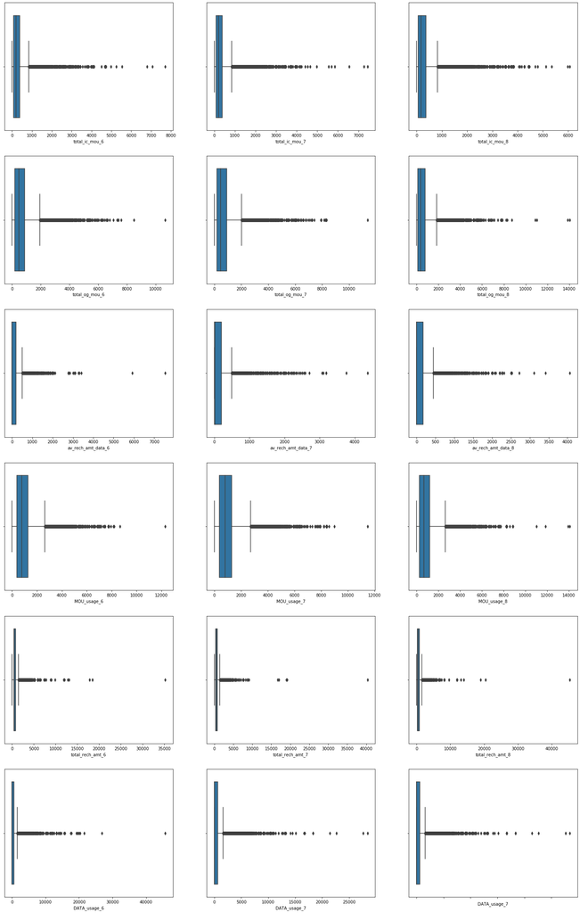

```python
# UNIVARIATE ANALYSIS


fig, axes = plt.subplots(nrows = 6,ncols = 3,figsize = (25,40))
sns.boxplot(x = "total_ic_mou_6", data = churn_data, ax=axes[0][0])
sns.boxplot(x = "total_ic_mou_7", data = churn_data, ax=axes[0][1])
sns.boxplot(x = "total_ic_mou_8", data = churn_data, ax=axes[0][2])

sns.boxplot(x = "total_og_mou_6", data = churn_data, ax=axes[1][0])
sns.boxplot(x = "total_og_mou_7", data = churn_data, ax=axes[1][1])
sns.boxplot(x = "total_og_mou_8", data = churn_data, ax=axes[1][2])

sns.boxplot(x = "av_rech_amt_data_6", data = churn_data, ax=axes[2][0])
sns.boxplot(x = "av_rech_amt_data_7", data = churn_data, ax=axes[2][1])
sns.boxplot(x = "av_rech_amt_data_8", data = churn_data, ax=axes[2][2])

sns.boxplot(x = "MOU_usage_6", data = churn_data, ax=axes[3][0])
sns.boxplot(x = "MOU_usage_7", data = churn_data, ax=axes[3][1])
sns.boxplot(x = "MOU_usage_8", data = churn_data, ax=axes[3][2])

sns.boxplot(x = "total_rech_amt_6", data = churn_data, ax=axes[4][0])
sns.boxplot(x = "total_rech_amt_7", data = churn_data, ax=axes[4][1])
sns.boxplot(x = "total_rech_amt_8", data = churn_data, ax=axes[4][2])


sns.boxplot(x = "DATA_usage_6", data = churn_data, ax=axes[5][0])
sns.boxplot(x = "DATA_usage_7", data = churn_data, ax=axes[5][1])
ax = sns.boxplot(x = "DATA_usage_7", data = churn_data, ax=axes[5][2])
ax.set_xticklabels(ax.get_xticklabels(),rotation=90)
plt.show(fig)
```

#### Looking at the distribution between churn and non-churn data

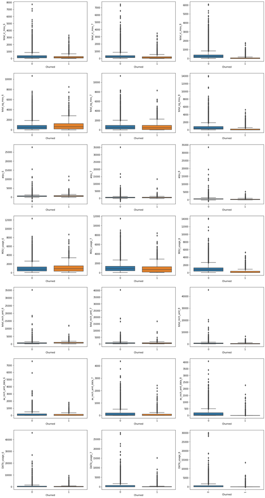

```python
fig, axes = plt.subplots(nrows = 7,ncols = 3,figsize = (20,40))
sns.boxplot(y = "total_ic_mou_6",x='Churned', data = churn_data, ax=axes[0][0])
sns.boxplot(y = "total_ic_mou_7",x='Churned', data = churn_data, ax=axes[0][1])
sns.boxplot(y = "total_ic_mou_8",x='Churned', data = churn_data, ax=axes[0][2])

sns.boxplot(y = "total_og_mou_6",x='Churned', data = churn_data, ax=axes[1][0])
sns.boxplot(y = "total_og_mou_7",x='Churned', data = churn_data, ax=axes[1][1])
sns.boxplot(y = "total_og_mou_8",x='Churned', data = churn_data, ax=axes[1][2])

sns.boxplot(y = "arpu_6",x='Churned', data = churn_data, ax=axes[2][0])
sns.boxplot(y = "arpu_7",x='Churned', data = churn_data, ax=axes[2][1])
sns.boxplot(y = "arpu_8",x='Churned', data = churn_data, ax=axes[2][2])

sns.boxplot(y = "MOU_usage_6",x='Churned', data = churn_data, ax=axes[3][0])
sns.boxplot(y = "MOU_usage_7",x='Churned', data = churn_data, ax=axes[3][1])
sns.boxplot(y = "MOU_usage_8",x='Churned', data = churn_data, ax=axes[3][2])

sns.boxplot(y = "total_rech_amt_6",x='Churned', data = churn_data, ax=axes[4][0])
sns.boxplot(y = "total_rech_amt_7",x='Churned', data = churn_data, ax=axes[4][1])
sns.boxplot(y = "total_rech_amt_8",x='Churned', data = churn_data, ax=axes[4][2])

sns.boxplot(y = "av_rech_amt_data_6",x='Churned', data = churn_data, ax=axes[5][0])
sns.boxplot(y = "av_rech_amt_data_7",x='Churned', data = churn_data, ax=axes[5][1])
sns.boxplot(y = "av_rech_amt_data_8",x='Churned', data = churn_data, ax=axes[5][2])

sns.boxplot(y = "DATA_usage_6",x='Churned', data = churn_data, ax=axes[6][0])
sns.boxplot(y = "DATA_usage_7",x='Churned', data = churn_data, ax=axes[6][1])
ax = sns.boxplot(y = "DATA_usage_8",x='Churned', data = churn_data, ax=axes[6][2])
ax.set_xticklabels(ax.get_xticklabels(),rotation=90)
plt.show(fig)
```

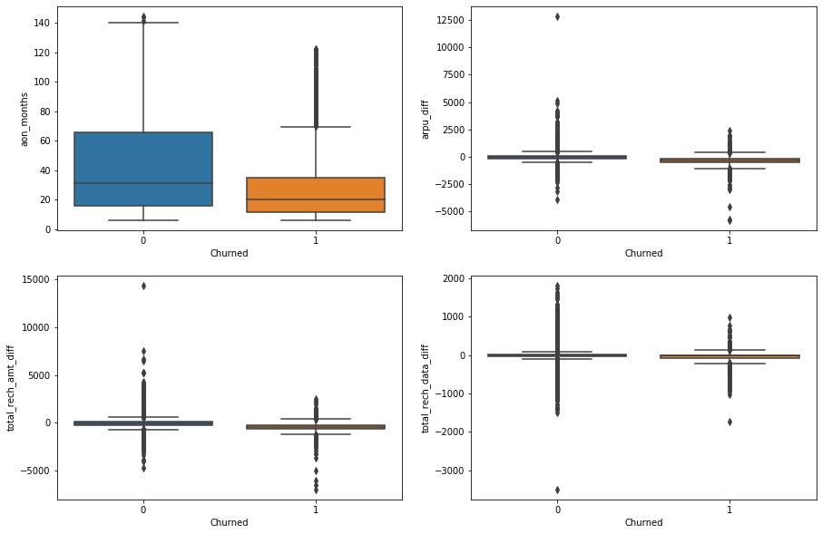

```python
# Difference plots that show how revenues change between 6+7 average and 8th month

fig, axes = plt.subplots(nrows = 2,ncols = 2,figsize = (15,10))
sns.boxplot(x = 'Churned', y = 'aon_months',data = churn_data, ax=axes[0][0])
sns.boxplot(x = 'Churned', y = 'arpu_diff',data = churn_data, ax=axes[0][1])
sns.boxplot(x = 'Churned', y = 'total_rech_amt_diff',data = churn_data, ax=axes[1][0])
sns.boxplot(x = 'Churned', y = 'total_rech_data_diff',data = churn_data, ax=axes[1][1])
ax.set_xticklabels(ax.get_xticklabels(),rotation=90)
plt.show(fig)
```

### 9) Finding Correlations

```python
#Find Highly correlated data . We choose 0.7 as the threshold.

churn_data['Churned'] = churn_data['Churned'].astype("int64")

cor = churn_data.corr()

cor.loc[:,:] = np.tril(cor, k=-1)
cor = cor.stack()
cor = cor[(cor > 0.70) | (cor < -0.70)].sort_values()
cor
```

```
std_ic_t2t_mou_8     std_ic_t2t_mou_7      0.700586
total_rech_amt_8     total_rech_amt_7      0.702042
loc_og_t2t_mou_8     loc_og_t2t_mou_6      0.702063
DATA_usage_7         vol_3g_mb_8           0.702909
jul_vbc_3g           aug_vbc_3g            0.704888
total_og_mou_6       onnet_mou_6           0.706486
loc_ic_mou_7         loc_ic_t2m_mou_8      0.706636
DATA_usage_8         vol_3g_mb_7           0.707847
loc_ic_t2m_mou_8     loc_ic_t2m_mou_6      0.708606
total_ic_mou_8       total_ic_mou_6        0.710783
std_ic_t2m_mou_8     std_ic_t2m_mou_7      0.710959
total_og_mou_7       onnet_mou_7           0.712141
loc_ic_mou_8         loc_ic_t2m_mou_7      0.712325
std_ic_t2f_mou_8     std_ic_t2f_mou_7      0.714255
std_ic_t2f_mou_7     std_ic_t2f_mou_6      0.718440
total_ic_mou_7       loc_ic_mou_6          0.718674
loc_og_mou_8         loc_og_mou_6          0.720721
offnet_mou_7         offnet_mou_6          0.721155
total_og_mou_7       offnet_mou_7          0.721756
sachet_2g_8          sachet_2g_7           0.722393
total_og_mou_6       offnet_mou_6          0.723440
total_og_mou_8       onnet_mou_8           0.725079
std_og_mou_7         std_og_mou_6          0.729884
                     std_og_t2t_mou_7      0.735096
std_og_t2m_mou_7     std_og_t2m_mou_6      0.736664
isd_ic_mou_8         isd_ic_mou_7          0.737197
std_og_t2t_mou_7     std_og_t2t_mou_6      0.737228
total_ic_mou_6       loc_ic_mou_7          0.737968
onnet_mou_7          onnet_mou_6           0.738222
std_ic_mou_8         std_ic_mou_7          0.738640
std_og_mou_6         std_og_t2t_mou_6      0.739886
loc_ic_mou_8         loc_ic_mou_6          0.740710
total_og_mou_8       offnet_mou_8          0.741070
DATA_usage_8         DATA_usage_7          0.741073
total_ic_mou_7       loc_ic_t2m_mou_7      0.741162
vol_3g_mb_8          vol_3g_mb_7           0.741278
total_ic_mou_7       loc_ic_mou_8          0.742041
std_ic_mou_7         std_ic_mou_6          0.742231
total_rech_amt_8     arpu_7                0.742406
std_ic_t2t_mou_7     std_ic_t2t_mou_6      0.742796
```

[output cut: 67 more lines]

```
total_ic_mou_8       loc_ic_mou_8          0.889182
total_ic_mou_6       loc_ic_mou_6          0.891694
MOU_usage_7          total_og_mou_7        0.898017
MOU_usage_6          total_og_mou_6        0.898167
MOU_usage_8          total_og_mou_8        0.906015
isd_og_mou_7         isd_og_mou_6          0.915203
isd_og_mou_8         isd_og_mou_6          0.916352
total_rech_amt_7     arpu_7                0.940108
isd_og_mou_8         isd_og_mou_7          0.941220
DATA_usage_7         vol_3g_mb_7           0.942936
DATA_usage_6         vol_3g_mb_6           0.943323
total_rech_amt_6     arpu_6                0.943627
DATA_usage_8         vol_3g_mb_8           0.951325
total_rech_amt_8     arpu_8                0.953597
dtype: float64
```

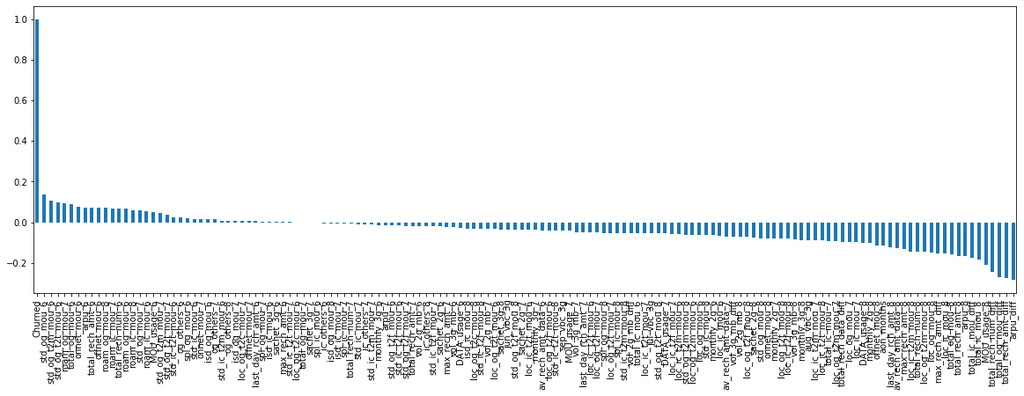

```python
#Get Correlation of "Churn" with other variables
# the correlation between churn and any variable is not very high.
# But many variables are intercorrelated since most are related to revenue and mou

plt.figure(figsize=(20,6))
churn_data.corr()['Churned'].sort_values(ascending = False).plot(kind='bar');
```

The results show that this data is highly correlated. Let us apply PCA modelling on this data.

```python
numeric_records = churn_data.select_dtypes(include=['float64'])
others_columns =  churn_data.select_dtypes(exclude=['float64'])
```

### 10) Function to cap outliers

```python
def cap_outliers(array, k=1):
    upper_limit = array.mean() + k*array.std()
    lower_limit = array.mean() - k*array.std()
    array[array<lower_limit] = lower_limit
    array[array>upper_limit] = upper_limit
    return array

# cap outliers in the numeric columns

churn_data[numeric_records.columns.tolist()] = churn_data[numeric_records.columns.tolist()].apply(cap_outliers, axis=0)
```

```python
churn_data.shape
```

```
(29949, 147)
```

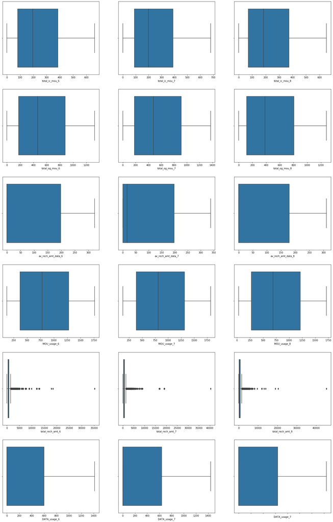

```python
# Box plot values after outlier treatement

fig, axes = plt.subplots(nrows = 6,ncols = 3,figsize = (25,40))
sns.boxplot(x = "total_ic_mou_6", data = churn_data, ax=axes[0][0])
sns.boxplot(x = "total_ic_mou_7", data = churn_data, ax=axes[0][1])
sns.boxplot(x = "total_ic_mou_8", data = churn_data, ax=axes[0][2])

sns.boxplot(x = "total_og_mou_6", data = churn_data, ax=axes[1][0])
sns.boxplot(x = "total_og_mou_7", data = churn_data, ax=axes[1][1])
sns.boxplot(x = "total_og_mou_8", data = churn_data, ax=axes[1][2])

sns.boxplot(x = "av_rech_amt_data_6", data = churn_data, ax=axes[2][0])
sns.boxplot(x = "av_rech_amt_data_7", data = churn_data, ax=axes[2][1])
sns.boxplot(x = "av_rech_amt_data_8", data = churn_data, ax=axes[2][2])

sns.boxplot(x = "MOU_usage_6", data = churn_data, ax=axes[3][0])
sns.boxplot(x = "MOU_usage_7", data = churn_data, ax=axes[3][1])
sns.boxplot(x = "MOU_usage_8", data = churn_data, ax=axes[3][2])

sns.boxplot(x = "total_rech_amt_6", data = churn_data, ax=axes[4][0])
sns.boxplot(x = "total_rech_amt_7", data = churn_data, ax=axes[4][1])
sns.boxplot(x = "total_rech_amt_8", data = churn_data, ax=axes[4][2])


sns.boxplot(x = "DATA_usage_6", data = churn_data, ax=axes[5][0])
sns.boxplot(x = "DATA_usage_7", data = churn_data, ax=axes[5][1])
ax = sns.boxplot(x = "DATA_usage_7", data = churn_data, ax=axes[5][2])
ax.set_xticklabels(ax.get_xticklabels(),rotation=90)
plt.show(fig)
```

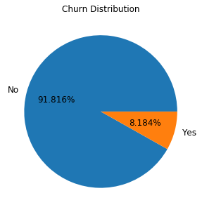

```python
#Churn Distribution.

# This is a problem with class imbalance. Hence we need to model taking this into account.
ax = (churn_data['Churned'].value_counts()*100.0 /len(churn_data)).plot.pie(autopct='%.3f%%', labels = ['No', 'Yes'],figsize =(5,5), fontsize = 12 )
ax.set_ylabel('',fontsize = 12)
ax.set_title('Churn Distribution', fontsize = 12)
```

```python
# Droping some columns that are correlated , derived

columns_to_keep = ['onnet_mou_6', 'onnet_mou_7', 'onnet_mou_8',
                   'offnet_mou_6', 'offnet_mou_7', 'offnet_mou_8',
                   'roam_ic_mou_6', 'roam_ic_mou_7', 'roam_ic_mou_8',
                   'roam_og_mou_6', 'roam_og_mou_7', 'roam_og_mou_8',
                   'loc_og_t2t_mou_6', 'loc_og_t2t_mou_7', 'loc_og_t2t_mou_8',
                   'loc_og_t2m_mou_6', 'loc_og_t2m_mou_7', 'loc_og_t2m_mou_8',
                   'loc_og_t2f_mou_6', 'loc_og_t2f_mou_7', 'loc_og_t2f_mou_8',
                   'loc_og_t2c_mou_6', 'loc_og_t2c_mou_7', 'loc_og_t2c_mou_8',
                   'loc_og_mou_6', 'loc_og_mou_7', 'loc_og_mou_8',
                   'std_og_t2t_mou_6', 'std_og_t2t_mou_7', 'std_og_t2t_mou_8',
                   'std_og_t2m_mou_6', 'std_og_t2m_mou_7', 'std_og_t2m_mou_8',
                   'std_og_t2f_mou_6', 'std_og_t2f_mou_7', 'std_og_t2f_mou_8',
                   'std_og_mou_6', 'std_og_mou_7', 'std_og_mou_8',
                   'isd_og_mou_6', 'isd_og_mou_7', 'isd_og_mou_8',
                   'spl_og_mou_6', 'spl_og_mou_7', 'spl_og_mou_8',
                   'og_others_6', 'og_others_7', 'og_others_8',
                   'loc_ic_t2t_mou_6', 'loc_ic_t2t_mou_7', 'loc_ic_t2t_mou_8',
                   'loc_ic_t2m_mou_6', 'loc_ic_t2m_mou_7', 'loc_ic_t2m_mou_8',
                   'loc_ic_t2f_mou_6', 'loc_ic_t2f_mou_7', 'loc_ic_t2f_mou_8',
                   'loc_ic_mou_6', 'loc_ic_mou_7', 'loc_ic_mou_8',
                   'std_ic_t2t_mou_6', 'std_ic_t2t_mou_7', 'std_ic_t2t_mou_8',
                   'std_ic_t2m_mou_6', 'std_ic_t2m_mou_7', 'std_ic_t2m_mou_8',
                   'std_ic_t2f_mou_6', 'std_ic_t2f_mou_7', 'std_ic_t2f_mou_8',
                   'std_ic_mou_6', 'std_ic_mou_7', 'std_ic_mou_8',
                   'spl_ic_mou_6', 'spl_ic_mou_7', 'spl_ic_mou_8',
                   'isd_ic_mou_6', 'isd_ic_mou_7', 'isd_ic_mou_8',
                   'ic_others_6', 'ic_others_7', 'ic_others_8',
                   'total_rech_amt_6', 'total_rech_amt_7', 'total_rech_amt_8',
                   'monthly_2g_6', 'monthly_2g_7', 'monthly_2g_8',
                   'sachet_2g_6', 'sachet_2g_7', 'sachet_2g_8',
                   'monthly_3g_6', 'monthly_3g_7', 'monthly_3g_8',
                   'sachet_3g_6', 'sachet_3g_7', 'sachet_3g_8',
                   'aug_vbc_3g', 'jul_vbc_3g', 'jun_vbc_3g',
                   'av_rech_amt_data_6', 'av_rech_amt_data_7', 'av_rech_amt_data_8',
                   'MOU_usage_6', 'MOU_usage_7', 'MOU_usage_8',
                   'DATA_usage_6', 'DATA_usage_7', 'DATA_usage_8',
                   'aon_months','fb_user_6', 'fb_user_7', 'fb_user_8', 'Churned']
churn_data = churn_data[columns_to_keep]

churn_data.shape
```

```
(29949, 113)
```

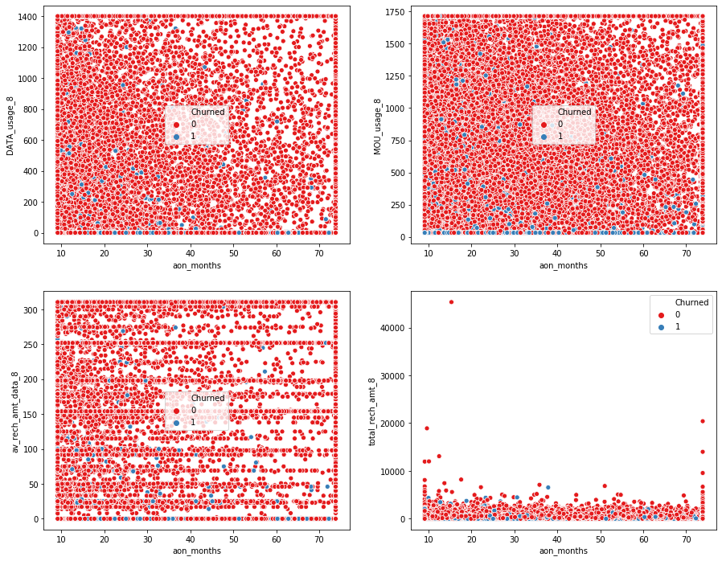

```python
fig, axes = plt.subplots(2,2, figsize=(15,12))
sns.scatterplot(x = 'aon_months', y = 'DATA_usage_8',hue='Churned',data = churn_data,legend='full',palette="Set1",ax=axes[0][0])
sns.scatterplot(x = 'aon_months', y = 'MOU_usage_8',hue='Churned', data = churn_data,legend='full',palette="Set1",ax=axes[0][1])
sns.scatterplot(x = 'aon_months', y = 'av_rech_amt_data_8',hue='Churned', data= churn_data,legend='full',palette="Set1",ax=axes[1][0])
sns.scatterplot(x = 'aon_months', y = 'total_rech_amt_8',hue='Churned', data= churn_data,legend='full',palette="Set1",ax=axes[1][1])
```

### 11) Modelling

### 11.1 Test Train Split

```python
## Splitting into traing and test

X=churn_data.drop('Churned',axis=1)
y=churn_data.Churned

from sklearn.model_selection import train_test_split
X_train, X_test, y_train, y_test = train_test_split(X, y, test_size = 0.30, random_state = 100, stratify = y)
```

```python
# Extracting column types
num_columns =numeric_columns = X.select_dtypes(exclude = 'category')
num_columns = num_columns.columns.tolist()

# import StandardScaler
from sklearn.preprocessing import StandardScaler

# apply StandardScaler
scaler = StandardScaler()

X_train[num_columns] = scaler.fit_transform(X_train[num_columns])
X_test[num_columns] = scaler.fit_transform(X_test[num_columns])

X_train.head()
```

|  | onnet_mou_6 | onnet_mou_7 | onnet_mou_8 | offnet_mou_6 | offnet_mou_7 | offnet_mou_8 | roam_ic_mou_6 | roam_ic_mou_7 | roam_ic_mou_8 | roam_og_mou_6 | roam_og_mou_7 | roam_og_mou_8 | loc_og_t2t_mou_6 | loc_og_t2t_mou_7 | loc_og_t2t_mou_8 | loc_og_t2m_mou_6 | loc_og_t2m_mou_7 | loc_og_t2m_mou_8 | loc_og_t2f_mou_6 | loc_og_t2f_mou_7 | loc_og_t2f_mou_8 | loc_og_t2c_mou_6 | loc_og_t2c_mou_7 | loc_og_t2c_mou_8 | loc_og_mou_6 | loc_og_mou_7 | loc_og_mou_8 | std_og_t2t_mou_6 | std_og_t2t_mou_7 | … |
| --- | --- | --- | --- | --- | --- | --- | --- | --- | --- | --- | --- | --- | --- | --- | --- | --- | --- | --- | --- | --- | --- | --- | --- | --- | --- | --- | --- | --- | --- | --- |
| 16167 | -0.733285 | -0.858097 | -0.813097 | -0.847989 | -1.156719 | -1.104649 | -0.366462 | -0.326604 | -0.329470 | -0.383405 | -0.355341 | -0.344661 | -0.611875 | -0.741490 | -0.720564 | -0.715458 | -1.034299 | -0.984490 | -0.556853 | -0.561851 | -0.555502 | -0.421605 | 1.402183 | -0.423974 | -0.735390 | -1.056632 | -1.005006 | -0.602192 | -0.602850 | … |
| 3498 | 2.130016 | 1.920964 | 1.724630 | 0.205034 | 0.479672 | 0.407812 | -0.366462 | -0.326604 | -0.329470 | -0.383405 | -0.355341 | -0.344661 | -0.433147 | -0.651537 | -0.643790 | 0.032019 | -0.042161 | -0.177534 | -0.556853 | -0.533750 | -0.555502 | -0.421605 | 0.562787 | 2.023880 | -0.228690 | -0.376562 | -0.449785 | 2.356318 | 2.337446 | … |
| 19790 | 2.130016 | 2.147759 | -0.675402 | 0.471253 | -0.818025 | -0.764154 | -0.366462 | -0.326604 | -0.329470 | -0.383405 | -0.355341 | -0.344661 | -0.156548 | -0.647607 | -0.587075 | -0.234228 | -0.626282 | -0.684488 | -0.556853 | -0.561851 | -0.555502 | -0.398311 | 2.725299 | -0.423974 | -0.289145 | -0.753313 | -0.697784 | 2.356318 | 2.337446 | … |
| 64552 | 2.130016 | 0.324792 | -0.815478 | -0.692353 | -0.996728 | -1.108120 | -0.366462 | 0.555874 | -0.160311 | -0.383405 | 0.780667 | -0.344661 | -0.488307 | -0.699490 | -0.727131 | -0.751192 | -0.862313 | -0.991566 | -0.556853 | -0.561851 | -0.555502 | -0.421605 | -0.415323 | -0.423974 | -0.765194 | -0.927724 | -1.012311 | 2.356318 | 0.746597 | … |
| 8186 | -0.871233 | -0.767744 | -0.814828 | 1.943261 | 0.904174 | -0.226067 | -0.366462 | -0.326604 | -0.329470 | -0.383405 | -0.355341 | -0.344661 | -0.743208 | -0.482300 | -0.725340 | 2.028575 | 2.003868 | 0.794602 | -0.556853 | -0.561851 | -0.555502 | 3.200458 | 3.027624 | 0.198292 | 2.014784 | 1.835307 | 0.147040 | -0.602192 | -0.602850 | … |

```python
import sklearn
from sklearn.cluster import KMeans
from sklearn.metrics import silhouette_score
from sklearn.decomposition import PCA
from sklearn.decomposition import IncrementalPCA


pca = PCA(random_state=42)
pca.fit(X)
pca.explained_variance_ratio_
```

```
array([3.54065712e-01, 1.75884602e-01, 9.89548825e-02, 8.50539823e-02,
       6.61614908e-02, 4.70713233e-02, 3.41322761e-02, 2.16593555e-02,
       1.61809020e-02, 1.40052226e-02, 1.28135384e-02, 1.15359880e-02,
       1.07162148e-02, 7.14406382e-03, 5.49453753e-03, 5.17061713e-03,
       4.42312899e-03, 3.03354076e-03, 2.50985179e-03, 2.42313568e-03,
       2.09043037e-03, 1.89244842e-03, 1.82491656e-03, 1.56803884e-03,
       1.51796290e-03, 1.23869870e-03, 1.21970098e-03, 1.06368694e-03,
       8.39178800e-04, 7.16689523e-04, 6.88524689e-04, 6.55842402e-04,
       6.36849004e-04, 5.55502819e-04, 4.67980988e-04, 4.47872514e-04,
       3.96089593e-04, 3.94186515e-04, 3.11298707e-04, 2.91555807e-04,
       2.26086520e-04, 2.18647764e-04, 2.10983163e-04, 1.98820110e-04,
       1.77214814e-04, 1.71465925e-04, 1.59053448e-04, 1.51028403e-04,
       1.49318096e-04, 1.27074190e-04, 1.15076830e-04, 1.03598507e-04,
       8.63170878e-05, 8.07088753e-05, 6.95099160e-05, 5.09962896e-05,
       4.89274863e-05, 4.39732744e-05, 3.76757453e-05, 3.46048080e-05,
       2.90369063e-05, 2.77023390e-05, 2.58811253e-05, 2.50446218e-05,
       2.11863015e-05, 2.02453654e-05, 1.80317069e-05, 1.58617091e-05,
       1.31576474e-05, 1.26249356e-05, 1.15474089e-05, 8.41139108e-06,
       8.08753966e-06, 7.51745684e-06, 6.98847050e-06, 6.48392677e-06,
       3.98009370e-06, 3.32641704e-06, 2.61703062e-06, 2.41563789e-06,
       2.27225848e-06, 1.91967431e-06, 1.78314476e-06, 1.69562869e-06,
       1.48090693e-06, 1.41799292e-06, 8.75125940e-07, 8.35528641e-07,
       8.22609822e-07, 7.14054033e-07, 6.84955195e-07, 5.76902566e-07,
       4.99448186e-07, 3.68753110e-07, 2.55591518e-07, 1.81344804e-07,
       1.39259509e-07, 1.05157537e-07, 7.95757208e-08, 6.24427518e-08,
       6.13982856e-08, 5.66094853e-08, 1.53329956e-08, 1.32614218e-08,
       1.18574485e-08, 7.06003726e-09, 4.82842830e-09, 4.28626252e-09,
       2.55628703e-09, 1.68958477e-09, 3.52489610e-10, 2.77985422e-10])
```

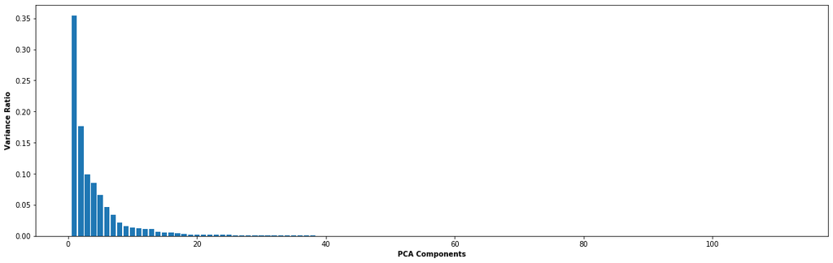

```python
plt.figure(figsize=(20,6))
plt.bar(range(1,len(pca.explained_variance_ratio_)+1), pca.explained_variance_ratio_)
plt.palette="Set1"
plt.xlabel("PCA Components",fontweight = 'bold')
plt.ylabel("Variance Ratio",fontweight = 'bold')
```

```python
var_cumu = np.cumsum(pca.explained_variance_ratio_)
var_cumu
```

```
array([0.35406571, 0.52995031, 0.6289052 , 0.71395918, 0.78012067,
       0.82719199, 0.86132427, 0.88298362, 0.89916453, 0.91316975,
       0.92598329, 0.93751928, 0.94823549, 0.95537955, 0.96087409,
       0.96604471, 0.97046784, 0.97350138, 0.97601123, 0.97843437,
       0.9805248 , 0.98241724, 0.98424216, 0.9858102 , 0.98732816,
       0.98856686, 0.98978656, 0.99085025, 0.99168943, 0.99240612,
       0.99309464, 0.99375048, 0.99438733, 0.99494284, 0.99541082,
       0.99585869, 0.99625478, 0.99664897, 0.99696027, 0.99725182,
       0.99747791, 0.99769656, 0.99790754, 0.99810636, 0.99828357,
       0.99845504, 0.99861409, 0.99876512, 0.99891444, 0.99904151,
       0.99915659, 0.99926019, 0.99934651, 0.99942721, 0.99949672,
       0.99954772, 0.99959665, 0.99964062, 0.9996783 , 0.9997129 ,
       0.99974194, 0.99976964, 0.99979552, 0.99982057, 0.99984175,
       0.999862  , 0.99988003, 0.99989589, 0.99990905, 0.99992167,
       0.99993322, 0.99994163, 0.99994972, 0.99995724, 0.99996423,
       0.99997071, 0.99997469, 0.99997802, 0.99998063, 0.99998305,
       0.99998532, 0.99998724, 0.99998903, 0.99999072, 0.9999922 ,
       0.99999362, 0.99999449, 0.99999533, 0.99999615, 0.99999687,
       0.99999755, 0.99999813, 0.99999863, 0.999999  , 0.99999925,
       0.99999943, 0.99999957, 0.99999968, 0.99999976, 0.99999982,
       0.99999988, 0.99999994, 0.99999995, 0.99999997, 0.99999998,
       0.99999999, 0.99999999, 1.        , 1.        , 1.        ,
       1.        , 1.        ])
```

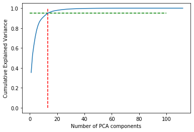

```python
plt.plot(range(1,len(var_cumu)+1), var_cumu)
plt.vlines(x=13, ymax=1, ymin=0, colors="r", linestyles="--")
plt.hlines(y=0.95, xmax=100, xmin=0, colors="g", linestyles="--")
plt.xlabel('Number of PCA components')
plt.ylabel('Cumulative Explained Variance')
```

```python
colnames = X.columns
attributes_pca =  pd.DataFrame(pca.components_)
attributes_pca = attributes_pca.loc[:,0:12]
attributes_pca['Attribute'] = colnames
attributes_pca.columns = ['PC1', 'PC2','PC3','PC4','PC5','PC6', 'PC7','PC8','PC9','PC10','PC11', 'PC12','PC13','Attribute']
attributes_pca.set_index("Attribute", inplace = True)
attributes_pca.head(10)
```

| Attribute | PC1 | PC2 | PC3 | PC4 | PC5 | PC6 | PC7 | PC8 | PC9 | PC10 | PC11 | PC12 | PC13 |
| --- | --- | --- | --- | --- | --- | --- | --- | --- | --- | --- | --- | --- | --- |
| onnet_mou_6 | 0.107248 | 0.122246 | 0.111593 | 0.143008 | 0.161839 | 0.147696 | 0.001167 | 0.000535 | 0.001044 | 0.002682 | 0.001395 | 0.002494 | 0.021792 |
| onnet_mou_7 | -0.056860 | -0.050610 | -0.021800 | -0.008083 | 0.004488 | 0.037564 | 0.001249 | 0.000756 | 0.001007 | 0.000649 | -0.000106 | 0.000768 | 0.012687 |
| onnet_mou_8 | 0.081320 | 0.108989 | 0.079146 | -0.083415 | -0.055397 | -0.065320 | 0.002534 | 0.002304 | 0.002512 | 0.007270 | 0.005838 | 0.006100 | -0.070364 |
| offnet_mou_6 | -0.061439 | -0.100866 | -0.107032 | 0.017340 | -0.035144 | -0.059444 | 0.003538 | 0.004820 | 0.003964 | 0.006802 | 0.008055 | 0.006544 | -0.001467 |
| offnet_mou_7 | 0.142788 | -0.002120 | -0.080466 | 0.190857 | -0.022680 | -0.130408 | -0.005444 | 0.000650 | 0.002129 | -0.009023 | 0.002515 | 0.003370 | 0.025475 |
| offnet_mou_8 | 0.316669 | 0.329252 | 0.277715 | -0.331844 | -0.386207 | -0.286824 | -0.001291 | -0.000655 | -0.000857 | -0.002310 | -0.001071 | -0.001420 | 0.055221 |
| roam_ic_mou_6 | -0.016752 | 0.119612 | -0.065140 | -0.083824 | 0.116683 | -0.146963 | -0.001314 | -0.002388 | 0.002552 | -0.003319 | -0.002454 | 0.004032 | 0.003835 |
| roam_ic_mou_7 | 0.058189 | -0.021283 | -0.044472 | 0.070365 | -0.025780 | -0.054749 | -0.007926 | 0.001207 | 0.003462 | -0.013560 | 0.003025 | 0.005682 | 0.012090 |
| roam_ic_mou_8 | 0.052407 | -0.088990 | 0.057855 | 0.062149 | -0.119777 | 0.084278 | -0.007045 | 0.006923 | -0.002489 | -0.010684 | 0.010223 | -0.003964 | 0.009675 |
| roam_og_mou_6 | -0.067306 | -0.101087 | -0.130964 | -0.068286 | -0.093556 | -0.144587 | -0.016697 | -0.003243 | 0.005561 | -0.032230 | -0.006232 | 0.007556 | -0.034514 |

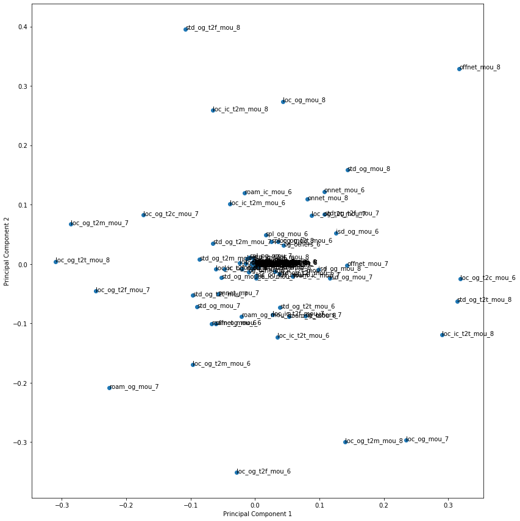

```python
#Let's visualise the first 2 components how it explains the varibles since it explains more than 50 percent of the variance

fig = plt.figure(figsize = (12,12))
plt.scatter(attributes_pca.PC1, attributes_pca.PC2)
plt.xlabel('Principal Component 1')
plt.ylabel('Principal Component 2')
for i, txt in enumerate(attributes_pca.index):
    plt.annotate(txt, (attributes_pca.PC1[i],attributes_pca.PC2[i]))
plt.tight_layout()
plt.show()
```

```python
# Incremental PCA
```

```python
pca_final = IncrementalPCA(n_components=13)
```

```python
df_final = pca_final.fit_transform(X)
```

```python
attributes_pca_2 = pd.DataFrame(df_final , columns = ['PC1', 'PC2','PC3','PC4','PC5','PC6', 'PC7','PC8','PC9','PC10','PC11', 'PC12','PC13'])
```

```python
attributes_pca_2.head()
```

|  | PC1 | PC2 | PC3 | PC4 | PC5 | PC6 | PC7 | PC8 | PC9 | PC10 | PC11 | PC12 | PC13 |
| --- | --- | --- | --- | --- | --- | --- | --- | --- | --- | --- | --- | --- | --- |
| 0 | -1460.655740 | -588.204549 | 137.971443 | 654.870883 | -238.184546 | -14.653541 | -45.395701 | -41.264623 | -73.122979 | -4.288861 | -45.619799 | 45.452278 | 4.404483 |
| 1 | 1422.019550 | 1431.237919 | -195.452408 | 1561.189845 | -578.339080 | -82.977424 | -1066.852322 | -483.401653 | -672.811370 | -1013.034276 | 57.866428 | 1145.682937 | 23.830205 |
| 2 | -946.954644 | -231.070046 | 125.702132 | 117.261082 | 162.892679 | -266.015119 | 427.708935 | -179.574465 | 627.706157 | 347.290831 | 55.299414 | 582.213289 | 289.521130 |
| 3 | -487.049320 | -654.513088 | -516.128819 | 454.038203 | -26.588965 | -4.252620 | 14.648234 | 36.498352 | -49.979690 | 68.924135 | -139.002223 | -24.733056 | -5.662501 |
| 4 | 1218.804890 | -644.850551 | 455.995637 | -304.765879 | -247.731569 | 1066.279152 | -315.783746 | 40.590473 | 102.461699 | 9.426816 | -45.674054 | -63.746714 | 15.610869 |

```python
pca_final.explained_variance_ratio_
```

```
array([0.35406565, 0.17588439, 0.09895454, 0.08505316, 0.06616105,
       0.04707075, 0.03413142, 0.02165675, 0.01617845, 0.01399973,
       0.01280689, 0.01152227, 0.01071324])
```

```python
# components relations with features:
results = pd.DataFrame(pca_final.components_,columns=colnames,index = ['PC1', 'PC2','PC3','PC4','PC5','PC6', 'PC7','PC8','PC9','PC10','PC11', 'PC12','PC13'])

results.head()
```

|  | onnet_mou_6 | onnet_mou_7 | onnet_mou_8 | offnet_mou_6 | offnet_mou_7 | offnet_mou_8 | roam_ic_mou_6 | roam_ic_mou_7 | roam_ic_mou_8 | roam_og_mou_6 | roam_og_mou_7 | roam_og_mou_8 | loc_og_t2t_mou_6 | loc_og_t2t_mou_7 | loc_og_t2t_mou_8 | loc_og_t2m_mou_6 | loc_og_t2m_mou_7 | loc_og_t2m_mou_8 | loc_og_t2f_mou_6 | loc_og_t2f_mou_7 | loc_og_t2f_mou_8 | loc_og_t2c_mou_6 | loc_og_t2c_mou_7 | loc_og_t2c_mou_8 | loc_og_mou_6 | loc_og_mou_7 | loc_og_mou_8 | std_og_t2t_mou_6 | std_og_t2t_mou_7 | … |
| --- | --- | --- | --- | --- | --- | --- | --- | --- | --- | --- | --- | --- | --- | --- | --- | --- | --- | --- | --- | --- | --- | --- | --- | --- | --- | --- | --- | --- | --- | --- |
| PC1 | 0.107244 | 0.122247 | 0.111596 | 0.143015 | 0.161840 | 0.147694 | 0.001168 | 0.000535 | 0.001044 | 0.002683 | 0.001396 | 0.002495 | 0.021788 | 0.025362 | 0.023973 | 0.037321 | 0.042187 | 0.039788 | 0.000652 | 0.000733 | 0.000692 | 0.000097 | 0.000134 | 0.000171 | 0.062826 | 0.072345 | 0.067704 | 0.070918 | 0.081543 | … |
| PC2 | -0.056858 | -0.050611 | -0.021810 | -0.008087 | 0.004489 | 0.037577 | 0.001250 | 0.000757 | 0.001009 | 0.000650 | -0.000104 | 0.000770 | 0.012685 | 0.015432 | 0.018916 | 0.030391 | 0.033194 | 0.039945 | 0.001599 | 0.001700 | 0.001681 | 0.000027 | 0.000049 | 0.000112 | 0.047411 | 0.054102 | 0.064012 | -0.066501 | -0.064359 | … |
| PC3 | 0.081289 | 0.109030 | 0.079235 | -0.083347 | -0.055406 | -0.065378 | 0.002541 | 0.002308 | 0.002516 | 0.007280 | 0.005844 | 0.006105 | -0.070350 | -0.067797 | -0.063133 | -0.154326 | -0.146169 | -0.134731 | -0.004467 | -0.004420 | -0.003956 | 0.000076 | 0.000237 | 0.000111 | -0.246395 | -0.237011 | -0.217306 | 0.147699 | 0.171398 | … |
| PC4 | -0.061461 | -0.100877 | -0.107048 | 0.017405 | -0.035086 | -0.059381 | 0.003548 | 0.004828 | 0.003972 | 0.006818 | 0.008066 | 0.006556 | -0.001565 | -0.008559 | -0.012416 | 0.020558 | 0.005741 | -0.004570 | 0.000805 | 0.000504 | 0.000258 | -0.000179 | -0.000322 | -0.000346 | 0.021869 | -0.001981 | -0.017077 | -0.055668 | -0.084367 | … |
| PC5 | 0.142740 | -0.002098 | -0.080443 | 0.190977 | -0.022703 | -0.130556 | -0.005445 | 0.000645 | 0.002120 | -0.009023 | 0.002509 | 0.003355 | 0.025480 | -0.003468 | -0.019789 | 0.045564 | -0.014852 | -0.046623 | 0.000643 | -0.000598 | -0.001276 | 0.000368 | -0.000077 | -0.000298 | 0.077806 | -0.020202 | -0.072035 | 0.102934 | -0.000202 | … |